# Coursework Report

*N* removed NAs: 3

*N* removed typo: 1

*N* removed <18: 14

*N* total clean: 132

| Group | *N* | *M*<sub>age</sub> | *M*<sub>rating</sub> |
| --- | --- | --- | --- |
| Control | 68 | 20.44 | 6.04 |
| Experim | 64 | 20.52 | 6.24 |

**Main analysis results**

*t*(130) = -1.32, *p* = .189

[interactive chart not shown]

[figure not shown]

[interactive chart not shown]

# Coursework Report

Analysing Data, Spring 2020

# Methods

## Participants

*Table 1* - Summary of Age Descriptives

| mean | sd | min | max |
| --- | --- | --- | --- |
| 20.48 | 1.89 | 18 | 25 |

*Table 2* - Descriptives of Age by Condition

| CONDITION | n | mean_age | sd_age |
| --- | --- | --- | --- |
| control | 68 | 20.44 | 1.79 |
| experimental | 64 | 20.52 | 2.00 |

## Design

In many nonhuman species the colour red signifies status and dominance, leading to greater success in mating and reproduction. Elliot et al (2010) conducted a study to analyse the effects that the colour red has on a males perceived attractiveness and general likeability. Findings from this study supported the idea that women did “perceive men to be more attractive and sexually desirable when seen on a red background and in red clothing” (Elliot et al 2010, pp399). My replication uses the same design as Elliot et al’s (2010) experiment 1. Therefore, my participants will either be allocated to the control or experimental condition and will only complete one Condition (between-subjects design).

Participants in the experimental condition will observe a photo of a male on a red background and then be asked the following items: “how attractive do you think the person is?”, “how pleasant is the person to look at?” and “if I was to meet this person face to face, I would think he was attractive” (Elliot et al 2010), each of these statements are variables for perceived attractiveness. Those in the control group would be given the same questions, however the man they were given to observe would have been pictured on a white background. These items are operationalised to measure perceived attractiveness and are answered by participants in both conditions using a 9-point rating scale. 1 being “not attractive at all” and 9 being “extremely attractive” (Elliot et al 2010). Perceived attractiveness is the operationalised dependent variable which will be measured using each of the different items. High scores in any of the three variables will infer that this participant finds the pictured male attractive and low scores will infer the opposite.

My operational hypothesis is that participants in the experimental group will provide higher ratings for perceived attractiveness compared to the control group. Furthermore, that the red coloured background will cause a significant difference in attractiveness ratings. After comparing the results I attain I will test my hypothesis using the t-test.

# Results

Table 3 below shows the mean score and standard deviation for each attractiveness rating, grouped by condition. By looking at the data we can see that “item 1” produces the largest difference between the two conditions with the experimental condition producing a slightly higher mean score, however these scores deviate more from the mean and the difference between the two mean scores is small.

However, arguably the most direct question (item 3) generates a different effect. In Table 3, the mean score shows that those in the control group gave higher ratings for item 3. This difference is insignificant, however, shows how the change in coloured background has had very little effect on attractiveness ratings.

*Table 3* - Mean and Standard Deviation for each Attractiveness Rating

| Condition | mean_item_1 | sd_item_1 | mean_item_2 | sd_item_2 | mean_item_3 | sd_item_3 |
| --- | --- | --- | --- | --- | --- | --- |
| control | 5.87 | 1.22 | 6.09 | 1.34 | 6.18 | 1.48 |
| experimental | 6.30 | 1.51 | 6.31 | 1.30 | 6.12 | 1.29 |

Table 4 below shows the mean attraction ratings for each condition. To calculate the composite scores, the means of each participants 3 ratings were gathered. The mean of these were then combined with the means of every other participant in the same condition to generate the average attraction rating for that condition. There was a minimal difference between the means of the experimental and control condition showing how the red effect was almost non-existent.

*Table 4* - Mean Attractiveness Score by Condition

| Condition | n | attract_mean |
| --- | --- | --- |
| control | 68 | 6.04 |
| experimental | 64 | 6.24 |

**Figure 1 - to show Mean Attraction Ratings for Control and Experimental Conditions**

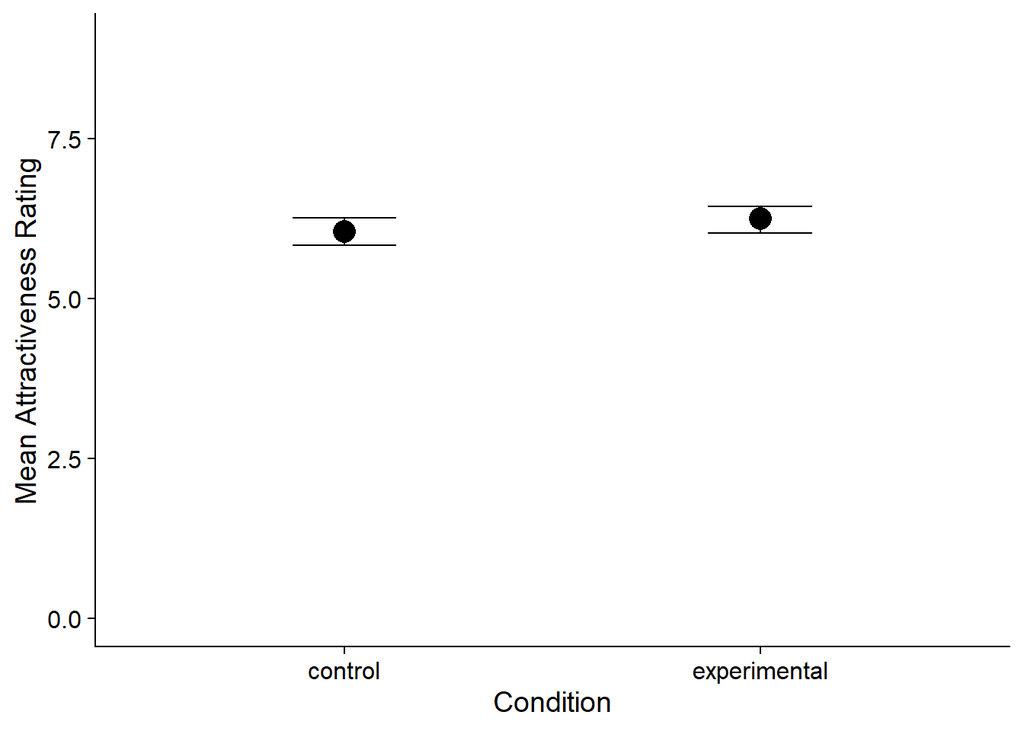

My alternative hypothesis that the colour red would cause a significant difference in attractiveness ratings, is incorrect. Therefore, I must reject the alternative hypothesis and accept the null hypothesis, that there is no significant difference.

# Discussion

My replication of Elliot et al’s (2010) experiment 1 showed no support for an effect of the colour red on attractiveness ratings. My results showed little to no difference in a males perceived attractiveness in combination with a red coloured background. These results are significantly different to those collected by Elliot et al (2010) who found a red effect significant to women’s perception of men. Elliot et al (2010) demonstrate that women found men more sexually desirable and attractive when in conjunction with the colour red. My results fail to display the same pattern in terms of perceived attractiveness (see results section for detailed analysis) when observed with a red coloured background. This implies that the “red effect” observed in Elliot et al’s (2010) study may not be as significant as suggested.

Hesslinger et al (2015) also conducted a study using a procedure similar to Elliot et al’s (2010) experiment 1. They presented an image of a male in either red clothing or in front of a red background, however, also varied the style of clothing worn by the male in the photo (casual or formal). Their results complimented my own as they also found no effect of the colour red in either of their variances (clothing or background).Pepperkoorn et al (2016) also extended the research into a red effect by conducting a study analysing coloured clothing (black, white and red). They aimed to establish whether red clothing influenced how males rated the attractiveness of a female. Like my results, this study found no support for the red effect. This further suggests that the effect of the colour red on a persons attractiveness is less significant than stated in Elliot et al’s (2010) study.

Hesslinger et al (2015) instead found an effect for the type of clothing worn in the image. Attractiveness ratings were higher for the image of the male in formal clothing compared to the same male in casual attire. This supports the idea that the status of a male influences perceived attractivenes, as formal attire may convey status more effectively than the colour red and casual attire. This provides direction for further studies as the type of clothing worn by both males and female’s may have a significant effect on perceived status and attractiveness as found in Hesslinger et al’s (2015) study.

Elliot & Maier (2012) established a theoretical framework to “understand the effects of colour on mate choice” (Elliot et al 2010 p399), with part of the model focusing the effect of colour on psychological functioning. Different colours carry certain connotations, for example the colour red is often seen in the context of love and attraction. A further area for study is to analyse the effect of both the colour red and high-status on perceived attractiveness. Lin (2014) studied a similar idea when testing how perceived attractiveness of a female changed when she was carrying a red laptop. The male participants rated the female as more attractive when carrying the red laptop, possibly indicating an effect when combining a high status product with the colour red. This study does not support my own as the experiment is instead designed to observe the effect on a females attractiveness rather than males. However, it does suggest that high-status in conjunction with the colour red may be an area worthy of further research.

My study was an effective investigation into the effect of the colour red on a males perceived attractiveness, the use of standardised phrases and images ensured each participant in the same condition experienced the same situation, minimising any variables which may have affected results. However, a weakness of my experiments design is that the use of Likert scale ratings provide answers which may differ between participants. For example, one participant’s extremely attractive (rating 9) is very achievable and similar to another participant’s expectation of rating 7. Furthermore, individual differences is a confounding variable which would’ve effected results. The female participants in my study would have preconceived opinions of what type of male they find attractive, therefore, some participants in the the experimental condition may find a male with brown hair unattractive despite wearing the colour red. These personal preferences are difficult variables to control and are a weakness of my experiment.

Overall, my study was an effective indicator of the insignificant effect of the colour red on perceived attractiveness in males. Despite limitations of the study, my experiment used a strong standardised design to analyse if there was a red effect. My results support the fact the colour red has minimal effect on perceived attractiveness in males, therefore, I conclude that the research question requires no more investigation. The same effect from Elliot et al’s (2010) has not been found in various studies as well as my own, so I do not believe the effect is real. Instead research should focus on high-status products and the effect these have on perceived attractiveness. For example, the inclusion of high-status products in a photograph and see how these effect likeability and sexual desirability. If an association is found, testing the high-status product in conjunction with the colour red may also provide a different effect.

# References

Elliot, A.J., Maier, M.A. (2012). Chapter 2 – Color-in-Context Theory. *Advances in Experimental Social Psychology. 45, 61-125.*

Elliot, A. J., Niesta Kayser, D., Greitemeyer, T., Lichtenfeld, S., Gramzow, R. H., Maier, M. A., & Liu, H. (2010). Red, rank, and romance in women viewing men. *Journal of Experimental Psychology: General, 139*(3), 399.

Hesslinger, Vera ; Goldbach, Lisa ; Carbon, Claus-Christian (2015). Men in red: A reexamination of the red-attractiveness effect. *Psychonomic Bulletin & Review, 22*(4), 1142-1148.

Lin, Hanyu., (2014). Red-coloured products enhance the attractiveness of women. *Displays. 35*(4), 202-205.

Peperkoorn, Leonard S ; Roberts, S. Craig ; Pollet, Thomas V., (2016). Revisiting the Red Effect on Attractiveness and Sexual Receptivity: No Effect of the Color Red on Human Mate Preferences *Evolutionary Psychology, 14*(4), 1-13.